# Forecasting Air Quality Index for Cincinnati (Part-1)

- Show All Code
- Hide All Code
- View Source

Author

Cariappa K S

Published

January 1, 2023

#### Section 1. Loading relevant R-packages and “Air Quality Index Dataset for Cincinnati”

(i). The data set for this project has been collected from the website of “United States - Environmental Protection Agency’s(EPA) Air Quality System (AQS)”. The Air Quality System (AQS) contains ambient air pollution data collected by EPA, state, local, and tribal air pollution control agencies from over thousands of monitors.

Link to download the dataset: https://www.epa.gov/outdoor-air-quality-data/air-data-multiyear-tile-plot

(ii). U.S. Air Quality Index (AQI) is EPA’s index for reporting air quality. The higher the AQI value, the greater the level of air pollution and greater the health concern. 50 or below represents good air quality whereas a value of 300 or more represents hazardous air quality. The AQI scores of five major pollutants - CO, NO2, Ozone, PM10 and PM2.5 are being tracked by the EPA.

Link to more details on AQI: https://www.airnow.gov/aqi/aqi-basics/

(iii). AQI is recorded at a daily granularity from 1980. The data is recorded for various cities/ counties across the US. I was curious about trying to predicting something as complex as the air quality index and as it was available for Cincinnati - I wanted to work on building a model whose output I can monitor. As Air Quality is impacted by several factors like sunshine, rain, temperature, wind speed and others along with the complexity of predicting the weather at a daily granularity, I think AQI will be a difficult variable to forecast.

(iv). The dependent variable is being taken as the maximum value of the APIs from five major pollutants. The daily AQI data has been downloaded for ‘Cincinnati’ from 01-01-2013 to 01-24-2023.

```r
library(readxl)
library(tidyverse)
library(lubridate)
library(ggplot2)
library(zoo)
library(tsibble)
library(feasts) #to enable autoplots on tsibble
library(fable)
library(fabletools)

#setting up local working directory and loading dataset
setwd('D:/1Spring/BANA 7050 Forecasting')
AQIdata <- as.data.frame(read_excel('AQI Cincinnati 01252023.xlsx',sheet = "AQI"))
AQIdata <- AQIdata[,c('Date','AQI Value')]
colnames(AQIdata) <- c('Date','AQI')

#Creating a tsibble object at daily granularity
AQIdata1 <- AQIdata %>%
  mutate(Date = as_date(Date)) %>%
  arrange(Date) %>%
  as_tsibble(index = Date)

#Creating a tsibble object at monthly granularity
AQIdata2<-AQIdata %>% filter(Date>="2017-01-01" & Date<="2022-12-31") %>%
  mutate(YM = yearmonth(Date,format = "%Y-%m-%d")) %>%
  group_by(YM) %>%
  summarize(value = mean(AQI)) %>%
  arrange(YM) %>%
  as_tsibble(index = YM)
```

#### Section 2. Exploratory Data Analysis

We observe peaks in AQI during months of June and July (summer) due to a variety of factors, such as increased temperatures, which can lead to the formation of ground-level ozone, and increased emissions from vehicles and other sources.

**Time Series at daily granularity (2021-2022)**

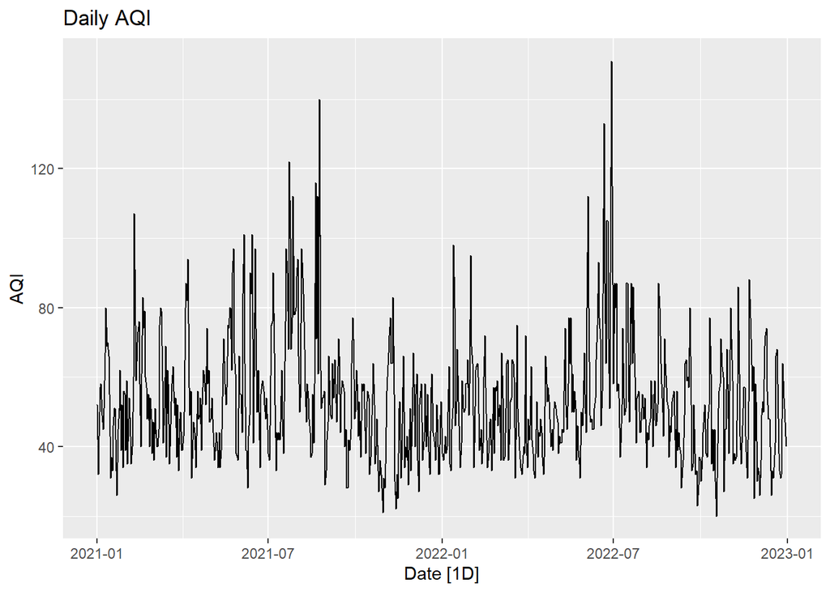

**Time Series at monthly granularity (2017-2022)**

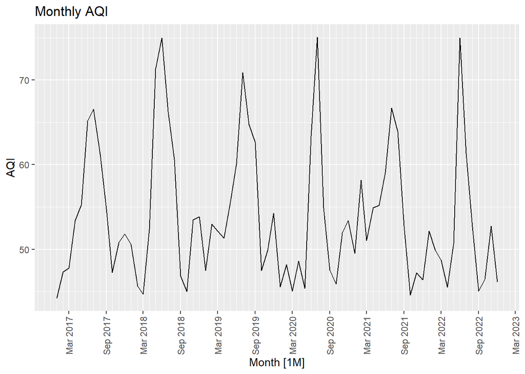

##### Checking the variation in AQI from 2017 to 2022

The mean value of AQI across years is ~53. AQI value of 51-100 indicates that air quality is “Moderate” in Cincinnati. However, there may be a risk for some people, particularly those who are unusually sensitive to air pollution. There are a few days which show AQI values from 101-150 indicating that air quality is “Unhealthy for Sensitive Groups”. This indicates that members of sensitive groups may experience health effects. The general public is less likely to be affected.

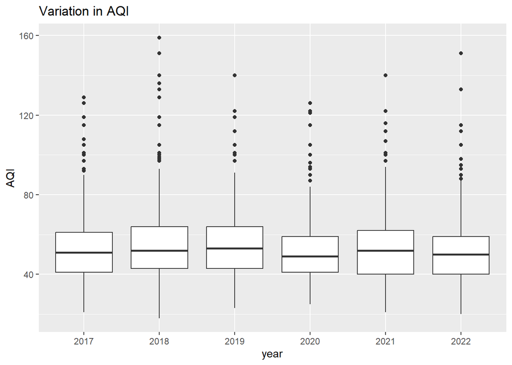

```r
AQIdata %>% mutate(year = as.character(year(AQIdata$Date))) %>%
  filter(Date>="2017-01-01" & Date<="2022-12-31") %>%
  ggplot(aes(x = year,y = AQI)) + geom_boxplot() +ggtitle('Variation in AQI')
```

##### Summary Statistics of AQI across years

```r
getmode <- function(v) {
   uniqv <- unique(v)
   uniqv[which.max(tabulate(match(v, uniqv)))]
}

AQIdata %>% mutate(year = as.character(year(AQIdata$Date))) %>%
  filter(Date>="2017-01-01" & Date<="2022-12-31") %>% group_by(year) %>%
  summarise(mean = round(mean(AQI),1),median=median(AQI),mode=getmode(AQI),standard_deviation =round(sd(AQI),1))
```

```
# A tibble: 6 × 5
  year   mean median  mode standard_deviation
  <chr> <dbl>  <dbl> <dbl>              <dbl>
1 2017   53.9     51    54               18
2 2018   55.5     52    48               20.2
3 2019   55.8     53    54               18.5
4 2020   52.1     49    50               17.2
5 2021   54.1     52    58               18
6 2022   52.2     50    51               17.2
```

##### Summary Statistics of AQI across months in 2022

```r
AQIdata %>% filter(Date>="2022-01-01" & Date<="2022-12-31") %>%
  mutate(YM = yearmonth(Date)) %>%
  group_by(YM) %>%
  summarise(mean = round(mean(AQI),1),median=median(AQI),mode=getmode(AQI),standard_deviation =round(sd(AQI),1))
```

```
# A tibble: 12 × 5
         YM  mean median  mode standard_deviation
      <mth> <dbl>  <dbl> <dbl>              <dbl>
 1 2022 Jan  52.6   50.5    51               16.3
 2 2022 Feb  49.9   47.5    57               12
 3 2022 Mar  48.7   46      51               12.7
 4 2022 Apr  45.5   44.5    53                9.3
 5 2022 May  50.7   50      51               11.8
 6 2022 Jun  75     71      80               28.2
 7 2022 Jul  61.3   56      87               16.2
 8 2022 Aug  52.7   51      48               11.6
 9 2022 Sep  45.1   41      56               13.4
10 2022 Oct  46.5   45      45               13.8
11 2022 Nov  52.8   54.5    56               17.1
12 2022 Dec  46.1   43      34               14.3
```

#### Section 3. Separate the “remainder” or random component from the more deterministic “trend” using moving averages

###### Moving Average are used to filter out the random component from the trend. They can be left/right/center aligned

Eg: A right-aligned moving average of order 3 would look like:

$$MA_{t} =\frac{Z_{t}+Z_{t-1}+Z_{t-2}}{3}$$

A center-aligned moving average of order 3 would look like:
$$MA_{t} =\frac{Z_{t-1}+Z_{t}+Z_{t+1}}{3}$$

###### Breaking down the AQI into trend and remainder using moving averages(MA) illustrates that there is a “Yearly Seasonality” in remainder where we see the AQI value goes up every year during summer (June,July).

**Daily AQI using center MA of 60 days**

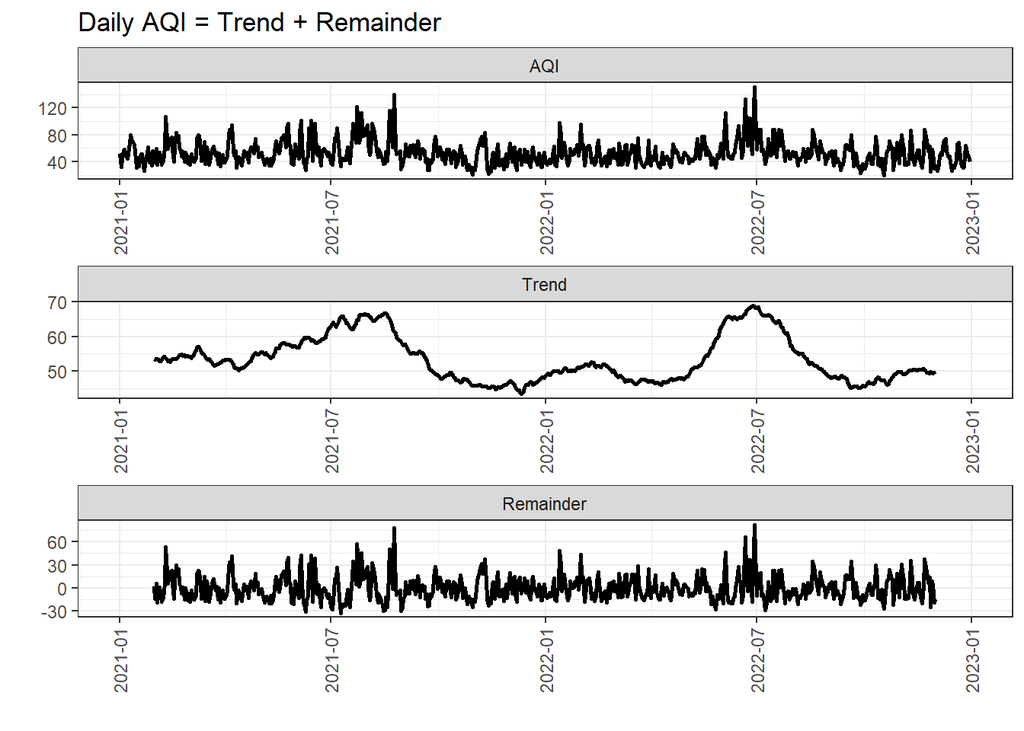

```r
colnames(AQIdata1) <- c('date','value')
AQIdata1_decomp <- AQIdata1 %>%
  mutate(
    ma_13_center = rollapply(
      value,
      60,
      FUN = mean,
      align = "center", fill = NA
    )
  ) %>%
  mutate(resid = value - ma_13_center) %>%
  select(date, value, ma_13_center, resid)

AQIdata1_decomp_plot <- AQIdata1_decomp %>%
  pivot_longer(
    value:resid,
    names_to = "decomposition",
    values_to = "value"
  ) %>%
  mutate(
    decomposition = case_when(
      decomposition == "value" ~ "Consumer Sentiment",
      decomposition == "ma_13_center" ~ "Trend",
      decomposition == "resid" ~ "Remainder"
    )
  ) %>%
  mutate(
    decomposition = factor(
      decomposition,
      labels = c(
        "AQI",
        "Trend",
        "Remainder"
      ),
      levels = c(
        "Consumer Sentiment",
        "Trend",
        "Remainder"
      )
    )
  ) %>%
  ggplot() +
  geom_line(aes(date, value,group=1), size = 1) +
  facet_wrap(
    ~decomposition,
    nrow = 3,
    scales = "free"
  ) +
  theme_bw() +
  ylab("") + theme(axis.text.x = element_text(angle = 90,hjust = 0.5,vjust = 0.5)) +
  xlab("") +
  ggtitle(
    "Daily AQI = Trend + Remainder"
  )

AQIdata1_decomp_plot
```

**Monthly AQI using right MA of 13 months**

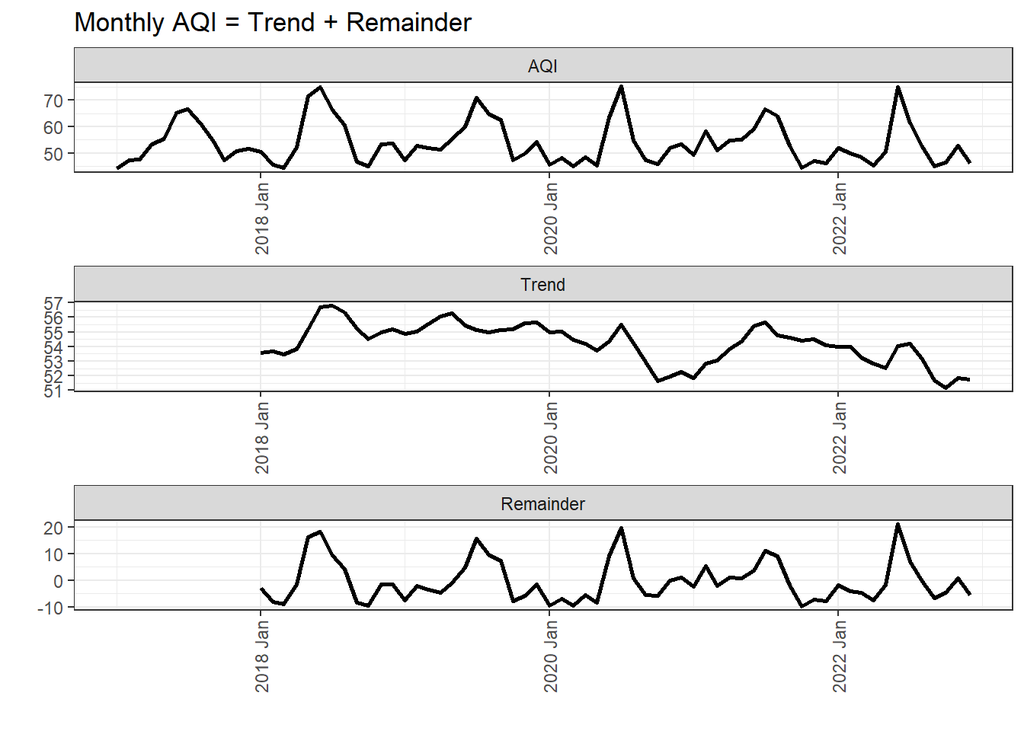

```r
colnames(AQIdata2) <- c('date','value')
AQIdata2_decomp <- AQIdata2 %>%
  mutate(
    ma_13_center = rollapply(
      value,
      13,
      FUN = mean,
      align = "right", fill = NA
    )
  ) %>%
  mutate(resid = value - ma_13_center) %>%
  select(date, value, ma_13_center, resid)

AQIdata2_decomp_plot <- AQIdata2_decomp %>%
  pivot_longer(
    value:resid,
    names_to = "decomposition",
    values_to = "value"
  ) %>%
  mutate(
    decomposition = case_when(
      decomposition == "value" ~ "Consumer Sentiment",
      decomposition == "ma_13_center" ~ "Trend",
      decomposition == "resid" ~ "Remainder"
    )
  ) %>%
  mutate(
    decomposition = factor(
      decomposition,
      labels = c(
        "AQI",
        "Trend",
        "Remainder"
      ),
      levels = c(
        "Consumer Sentiment",
        "Trend",
        "Remainder"
      )
    )
  ) %>%
  ggplot() +
  geom_line(aes(date, value,group=1), size = 1) +
  facet_wrap(
    ~decomposition,
    nrow = 3,
    scales = "free"
  ) +
  theme_bw() +
  ylab("") + theme(axis.text.x = element_text(angle = 90,hjust = 0.5,vjust = 0.5)) +
  xlab("") +
  ggtitle(
    "Monthly AQI = Trend + Remainder"
  )

AQIdata2_decomp_plot
```

##### Using Time Series Decomposition to break “remainder” into ‘seasonal’ and ‘white noise’ components

**Types of Seasonality**

1. **Additive:** Impact of seasonality constant over time (
   $$y_{t} = S_{t} + T_{t} + R_t$$
   )
2. **Multiplicative:** Seasonal effects increasing/decreasing over time (
   $$y_{t} = S_{t} * T_{t} * R_t$$
   )

##### We do not see variations in AQI increasing/decreasing over years, additive classical decomposition can be used here.

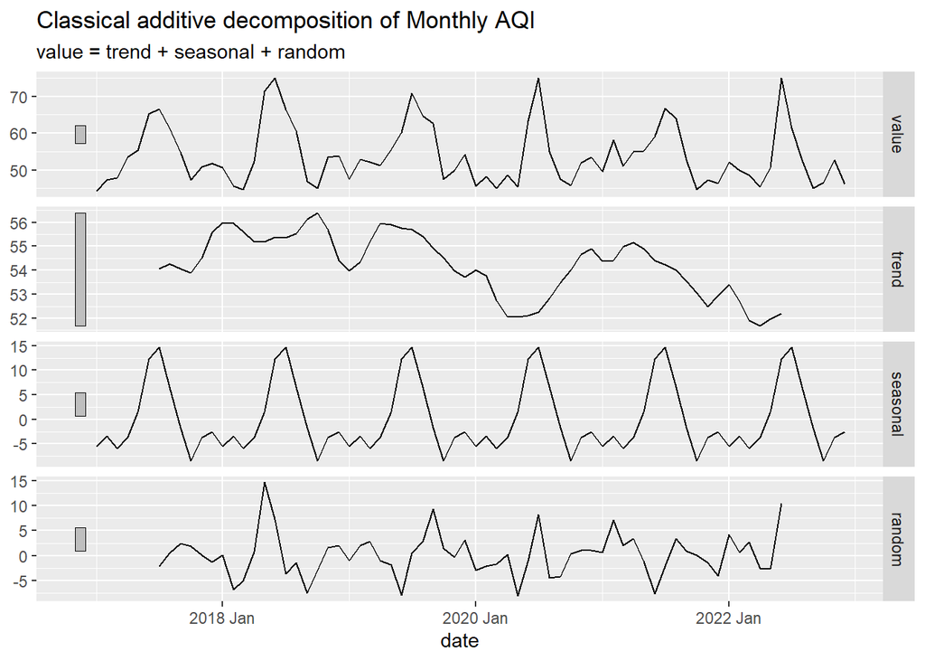

```r
AQIdata2_decomp <- AQIdata2 %>%
  model(classical_decomposition(value,type = 'additive')) %>%
  components()

AQIdata2_decomp %>% autoplot() + labs(title = "Classical additive decomposition of Monthly AQI")
```

Naive forecast suggests forecasts in line with the data trends with dip in AQI at the beginning of 2023 and then it is sharply increasing towards mid of 2023.

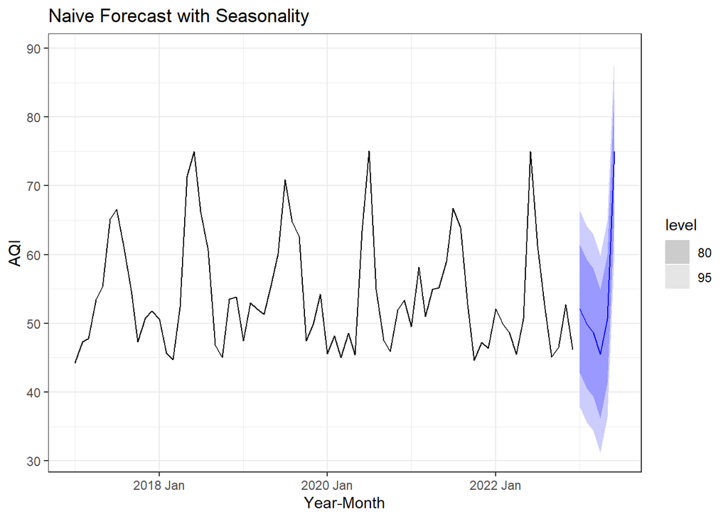

```r
#Naive Forecast
AQIdata2 %>%
  model(SNAIVE(value)) %>%
  forecast(h=6) %>%
  autoplot(AQIdata2 %>% bind_rows())+
  theme_bw()+
  labs(title = "Naive Forecast with Seasonality",
       y = "AQI",
       x = "Year-Month")
```